# Exploratory Data Analysis

```python
import os

import numpy as np
import pandas as pd
import matplotlib.pyplot as plt
```

```python
rating_columns = ["user_id", "movie_id", "ratings", "timestamp"]
df_rating = pd.read_csv(r"C:/Users/chipp/Downloads/Assignment-2/ml-100k/ml-100k/u.data",sep='\t', names=rating_columns)
```

```python
movies_cols = ['movie_id', 'title', 'release_date', 'video_release_date', 'imdb_url']
df_movies = pd.read_csv(r"C:/Users/chipp/Downloads/Assignment-2/ml-100k/ml-100k/u.item", sep='|', encoding='latin-1', usecols=range(5),
names=movies_cols)
```

```python
user_columns = ['user_id', 'age', 'gender', 'occupation', 'zip_code']
df_users = pd.read_csv(r"C:/Users/chipp/Downloads/Assignment-2/ml-100k/ml-100k/u.user", sep='|', names=user_columns)
```

### Q1). Use the info() and describe() methods to get general information about each of the DataFrames

#### Exploring Ratings dataframe

```python
df_rating.info()
```

```
<class 'pandas.core.frame.DataFrame'>
RangeIndex: 100000 entries, 0 to 99999
Data columns (total 4 columns):
 #   Column     Non-Null Count   Dtype
---  ------     --------------   -----
 0   user_id    100000 non-null  int64
 1   movie_id   100000 non-null  int64
 2   ratings    100000 non-null  int64
 3   timestamp  100000 non-null  int64
dtypes: int64(4)
memory usage: 3.1 MB
```

```python
df_rating.describe()
```

|  | user_id | movie_id | ratings | timestamp |
| --- | --- | --- | --- | --- |
| count | 100000.00000 | 100000.000000 | 100000.000000 | 1.000000e+05 |
| mean | 462.48475 | 425.530130 | 3.529860 | 8.835289e+08 |
| std | 266.61442 | 330.798356 | 1.125674 | 5.343856e+06 |
| min | 1.00000 | 1.000000 | 1.000000 | 8.747247e+08 |
| 25% | 254.00000 | 175.000000 | 3.000000 | 8.794487e+08 |
| 50% | 447.00000 | 322.000000 | 4.000000 | 8.828269e+08 |
| 75% | 682.00000 | 631.000000 | 4.000000 | 8.882600e+08 |
| max | 943.00000 | 1682.000000 | 5.000000 | 8.932866e+08 |

#### Exploring Movies Dataframe

```python
df_movies.info()
```

```
<class 'pandas.core.frame.DataFrame'>
RangeIndex: 1682 entries, 0 to 1681
Data columns (total 5 columns):
 #   Column              Non-Null Count  Dtype
---  ------              --------------  -----
 0   movie_id            1682 non-null   int64
 1   title               1682 non-null   object
 2   release_date        1681 non-null   object
 3   video_release_date  0 non-null      float64
 4   imdb_url            1679 non-null   object
dtypes: float64(1), int64(1), object(3)
memory usage: 65.8+ KB
```

```python
df_movies.describe()
```

|  | movie_id | video_release_date |
| --- | --- | --- |
| count | 1682.000000 | 0.0 |
| mean | 841.500000 | NaN |
| std | 485.695893 | NaN |
| min | 1.000000 | NaN |
| 25% | 421.250000 | NaN |
| 50% | 841.500000 | NaN |
| 75% | 1261.750000 | NaN |
| max | 1682.000000 | NaN |

#### Exploring Users Dataframe

```python
df_users.info()
```

```
<class 'pandas.core.frame.DataFrame'>
RangeIndex: 943 entries, 0 to 942
Data columns (total 5 columns):
 #   Column      Non-Null Count  Dtype
---  ------      --------------  -----
 0   user_id     943 non-null    int64
 1   age         943 non-null    int64
 2   gender      943 non-null    object
 3   occupation  943 non-null    object
 4   zip_code    943 non-null    object
dtypes: int64(2), object(3)
memory usage: 37.0+ KB
```

```python
df_users.describe()
```

|  | user_id | age |
| --- | --- | --- |
| count | 943.000000 | 943.000000 |
| mean | 472.000000 | 34.051962 |
| std | 272.364951 | 12.192740 |
| min | 1.000000 | 7.000000 |
| 25% | 236.500000 | 25.000000 |
| 50% | 472.000000 | 31.000000 |
| 75% | 707.500000 | 43.000000 |
| max | 943.000000 | 73.000000 |

### Q2). Use the head() method to show the first few rows of each DataFrame.

```python
df_rating.head()
```

|  | user_id | movie_id | ratings | timestamp |
| --- | --- | --- | --- | --- |
| 0 | 196 | 242 | 3 | 881250949 |
| 1 | 186 | 302 | 3 | 891717742 |
| 2 | 22 | 377 | 1 | 878887116 |
| 3 | 244 | 51 | 2 | 880606923 |
| 4 | 166 | 346 | 1 | 886397596 |

```python
df_movies.head()
```

|  | movie_id | title | release_date | video_release_date | imdb_url |
| --- | --- | --- | --- | --- | --- |
| 0 | 1 | Toy Story (1995) | 01-Jan-1995 | NaN | http://us.imdb.com/M/title-exact?Toy%20Story%2... |
| 1 | 2 | GoldenEye (1995) | 01-Jan-1995 | NaN | http://us.imdb.com/M/title-exact?GoldenEye%20(... |
| 2 | 3 | Four Rooms (1995) | 01-Jan-1995 | NaN | http://us.imdb.com/M/title-exact?Four%20Rooms%... |
| 3 | 4 | Get Shorty (1995) | 01-Jan-1995 | NaN | http://us.imdb.com/M/title-exact?Get%20Shorty%... |
| 4 | 5 | Copycat (1995) | 01-Jan-1995 | NaN | http://us.imdb.com/M/title-exact?Copycat%20(1995) |

```python
df_users.head()
```

|  | user_id | age | gender | occupation | zip_code |
| --- | --- | --- | --- | --- | --- |
| 0 | 1 | 24 | M | technician | 85711 |
| 1 | 2 | 53 | F | other | 94043 |
| 2 | 3 | 23 | M | writer | 32067 |
| 3 | 4 | 24 | M | technician | 43537 |
| 4 | 5 | 33 | F | other | 15213 |

### Q3). How many rows of data does each DataFrame have?

**Number of rows in rating dataframe**

```python
len(df_rating)
```

```
100000
```

**Number of rows in movies dataframe**

```python
len(df_movies)
```

```
1682
```

**Number of rows in users dataframe**

```python
len(df_users)
```

```
943
```

### Q4). Find the unique values and the number of unique values in the ‘rating’ column of the df_ratings. (Hint: use the unique() and nunique() methods).

```python
print(f"The unique values in the ratings column are : {df_rating['ratings'].unique()}")
```

```
The unique values in the ratings column are : [3 1 2 4 5]
```

```python
print(f"The number of unique values in the ratings column is : {df_rating['ratings'].nunique()}")
```

```
The number of unique values in the ratings column is : 5
```

### Q5). Find the number of unique values in the column 'user_id'. What does this number represent?

```python
print(f"The number of unique values in the user id column is : {df_rating['user_id'].nunique()}")
print()
print()
print("The user id column in the dataframe represents the unique user id for each user.")
```

```
The number of unique values in the user id column is : 943


The user id column in the dataframe represents the unique user id for each user.
```

### Q6). Show a histogram of the number of times each of the ratings were used

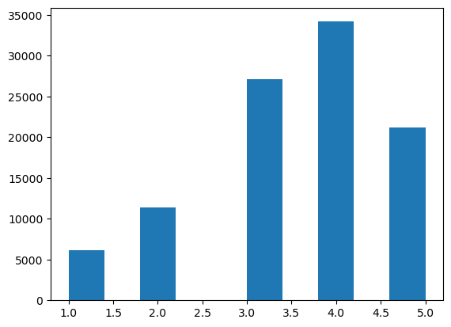

```python
plt.hist(x=df_rating['ratings'])
```

### Q7). Which movie was rated the greatest number of times.

```python
movie_ratings_count = df_movies['title'].value_counts()
most_rated_movie = movie_ratings_count.idxmax()
print("Movie with the greatest number of ratings:", most_rated_movie)
```

[output not shown]

```python
five_ratings_df = df_rating[df_rating['ratings'] == 5]
most_frequent_movie_id = five_ratings_df['movie_id'].value_counts().idxmax()
print("Movie ID with the most '5' ratings:", most_frequent_movie_id)
```

```
Movie ID with the most '5' ratings: 50
```

### Q9). Plot a histogram of the frequency of ratings by user.

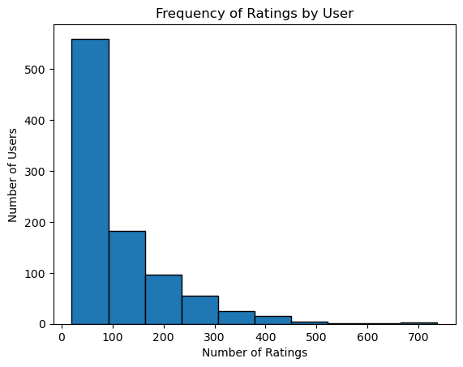

```python
user_ratings_count = df_rating['user_id'].value_counts()

plt.hist(user_ratings_count, bins=10, edgecolor='k')
plt.xlabel('Number of Ratings')
plt.ylabel('Number of Users')
plt.title('Frequency of Ratings by User')
plt.show()
```

### Q10). What is the date with the greatest number of movies released?

```python
df_movies['release_date'] = pd.to_datetime(df_movies['release_date'])
movie_counts_by_date = df_movies['release_date'].value_counts()
date_with_most_movies = movie_counts_by_date.idxmax()
print("Date with the greatest number of movies released:", date_with_most_movies)
```

```
Date with the greatest number of movies released: 1995-01-01 00:00:00
```

### Q11). Merge the DataFrames for ratings and movies data for a comprehensive dataset. Display a sample of rows from this combined DataFrame

```python
new_df = pd.merge(df_rating, df_movies, on='movie_id')
new_df.head()
```

|  | user_id | movie_id | ratings | timestamp | title | release_date | video_release_date | imdb_url |
| --- | --- | --- | --- | --- | --- | --- | --- | --- |
| 0 | 196 | 242 | 3 | 881250949 | Kolya (1996) | 1997-01-24 | NaN | http://us.imdb.com/M/title-exact?Kolya%20(1996) |
| 1 | 63 | 242 | 3 | 875747190 | Kolya (1996) | 1997-01-24 | NaN | http://us.imdb.com/M/title-exact?Kolya%20(1996) |
| 2 | 226 | 242 | 5 | 883888671 | Kolya (1996) | 1997-01-24 | NaN | http://us.imdb.com/M/title-exact?Kolya%20(1996) |
| 3 | 154 | 242 | 3 | 879138235 | Kolya (1996) | 1997-01-24 | NaN | http://us.imdb.com/M/title-exact?Kolya%20(1996) |
| 4 | 306 | 242 | 5 | 876503793 | Kolya (1996) | 1997-01-24 | NaN | http://us.imdb.com/M/title-exact?Kolya%20(1996) |

### Q12). How many times was the movie 'Star Wars (1977)' rated?

```python
star_wars_ratings_count = new_df[new_df['title'] == 'Star Wars (1977)']['ratings'].count()
print("Number of times 'Star Wars (1977)' was rated:", star_wars_ratings_count)
```

```
Number of times 'Star Wars (1977)' was rated: 583
```

### Q13). A Histogram using the number of ratings per movie

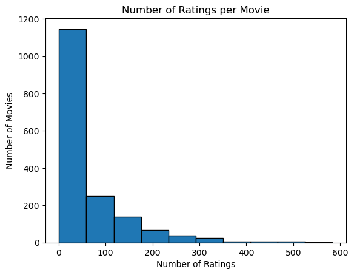

```python
ratings_per_movie = new_df.groupby('movie_id').size()

plt.hist(ratings_per_movie, bins=10, edgecolor='k')
plt.xlabel('Number of Ratings')
plt.ylabel('Number of Movies')
plt.title('Number of Ratings per Movie')
plt.show()
```

### Q14). Show a bar chart of the top-rated movies.

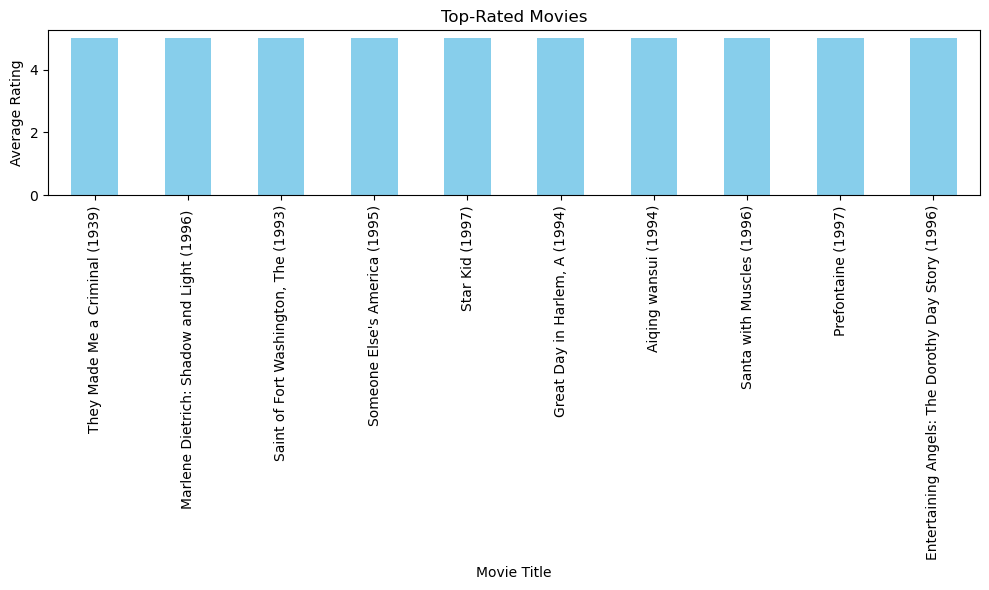

```python
average_ratings = new_df.groupby('title')['ratings'].mean()
top_rated_movies = average_ratings.sort_values(ascending=False)
top_10_rated_movies = top_rated_movies.head(10)
plt.figure(figsize=(10, 6))
top_10_rated_movies.plot(kind='bar', color='skyblue')
plt.xlabel('Movie Title')
plt.ylabel('Average Rating')
plt.title('Top-Rated Movies')

plt.tight_layout()
plt.show()
```

**Note: the fiqure seems to be distorted hence, limiting the movies count to 10**

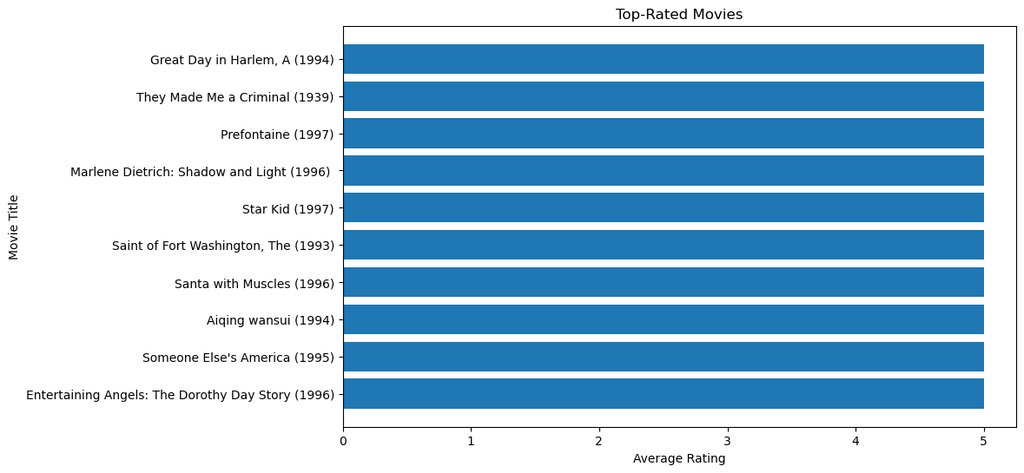

```python
top_rated_movies = new_df.groupby('movie_id')['ratings'].mean().sort_values(ascending=False).head(10)
top_rated_movie_titles = df_movies[df_movies['movie_id'].isin(top_rated_movies.index)]['title']
plt.figure(figsize=(10, 6))
plt.barh(top_rated_movie_titles, top_rated_movies)
plt.xlabel('Average Rating')
plt.ylabel('Movie Title')
plt.title('Top-Rated Movies')
plt.gca().invert_yaxis()
plt.show()
```

### Q15). Merge the user DataFrame with the previously merged DataFrame for users and movies data.

```python
merged_df = pd.merge(new_df, df_users, on='user_id')
merged_df.head()
```

|  | user_id | movie_id | ratings | timestamp | title | release_date | video_release_date | imdb_url | age | gender | occupation | zip_code |
| --- | --- | --- | --- | --- | --- | --- | --- | --- | --- | --- | --- | --- |
| 0 | 196 | 242 | 3 | 881250949 | Kolya (1996) | 1997-01-24 | NaN | http://us.imdb.com/M/title-exact?Kolya%20(1996) | 49 | M | writer | 55105 |
| 1 | 196 | 257 | 2 | 881251577 | Men in Black (1997) | 1997-07-04 | NaN | http://us.imdb.com/M/title-exact?Men+in+Black+... | 49 | M | writer | 55105 |
| 2 | 196 | 111 | 4 | 881251793 | Truth About Cats & Dogs, The (1996) | 1996-04-26 | NaN | http://us.imdb.com/M/title-exact?Truth%20About... | 49 | M | writer | 55105 |
| 3 | 196 | 25 | 4 | 881251955 | Birdcage, The (1996) | 1996-03-08 | NaN | http://us.imdb.com/M/title-exact?Birdcage,%20T... | 49 | M | writer | 55105 |
| 4 | 196 | 382 | 4 | 881251843 | Adventures of Priscilla, Queen of the Desert, ... | 1994-01-01 | NaN | http://us.imdb.com/M/title-exact?Adventures%20... | 49 | M | writer | 55105 |

### Q16). Count the number of ratings and average rating for each movie.

```python
rating_counts = merged_df.groupby('title')['ratings'].count()
average_ratings = merged_df.groupby('title')['ratings'].mean()
movie_ratings_summary = pd.DataFrame({'Rating Count': rating_counts, 'Average Rating': average_ratings})
movie_ratings_summary
```

| title | Rating Count | Average Rating |
| --- | --- | --- |
| 'Til There Was You (1997) | 9 | 2.333333 |
| 1-900 (1994) | 5 | 2.600000 |
| 101 Dalmatians (1996) | 109 | 2.908257 |
| 12 Angry Men (1957) | 125 | 4.344000 |
| 187 (1997) | 41 | 3.024390 |
| ... | ... | ... |
| Young Guns II (1990) | 44 | 2.772727 |
| Young Poisoner's Handbook, The (1995) | 41 | 3.341463 |
| Zeus and Roxanne (1997) | 6 | 2.166667 |
| unknown | 9 | 3.444444 |
| Á köldum klaka (Cold Fever) (1994) | 1 | 3.000000 |

1664 rows × 2 columns

```python
movie_ratings_summary[movie_ratings_summary['Rating Count']>= 100]
```

| title | Rating Count | Average Rating |
| --- | --- | --- |
| 101 Dalmatians (1996) | 109 | 2.908257 |
| 12 Angry Men (1957) | 125 | 4.344000 |
| 2001: A Space Odyssey (1968) | 259 | 3.969112 |
| Absolute Power (1997) | 127 | 3.370079 |
| Abyss, The (1989) | 151 | 3.589404 |
| ... | ... | ... |
| Willy Wonka and the Chocolate Factory (1971) | 326 | 3.631902 |
| Wizard of Oz, The (1939) | 246 | 4.077236 |
| Wrong Trousers, The (1993) | 118 | 4.466102 |
| Young Frankenstein (1974) | 200 | 3.945000 |
| Young Guns (1988) | 101 | 3.207921 |

338 rows × 2 columns

### Q18). Find the average rating for each movie by gender. Draw a histogram for each gender.

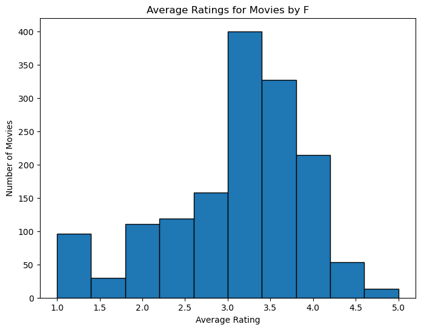

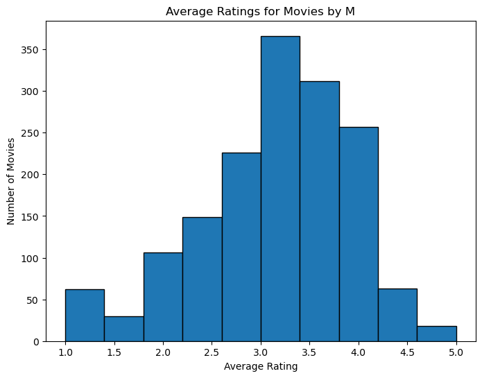

```python
avg_rating_by_gender = merged_df.groupby(['title', 'gender'])['ratings'].mean().unstack()

for gender in avg_rating_by_gender.columns:
    plt.figure(figsize=(8, 6))
    plt.hist(avg_rating_by_gender[gender], bins=10, edgecolor='k')
    plt.xlabel('Average Rating')
    plt.ylabel('Number of Movies')
    plt.title(f'Average Ratings for Movies by {gender}')
    plt.show()
```

### Q19). Give a list of the number of people in each occupation in descending order.

```python
occupation_counts = df_users['occupation'].value_counts().reset_index()
occupation_counts.columns = ['Occupation', 'Number of People']
occupation_counts_sorted = occupation_counts.sort_values(by='Number of People', ascending=False)
occupation_counts_sorted
```

|  | Occupation | Number of People |
| --- | --- | --- |
| 0 | student | 196 |
| 1 | other | 105 |
| 2 | educator | 95 |
| 3 | administrator | 79 |
| 4 | engineer | 67 |
| 5 | programmer | 66 |
| 6 | librarian | 51 |
| 7 | writer | 45 |
| 8 | executive | 32 |
| 9 | scientist | 31 |
| 10 | artist | 28 |
| 11 | technician | 27 |
| 12 | marketing | 26 |
| 13 | entertainment | 18 |
| 14 | healthcare | 16 |
| 15 | retired | 14 |
| 16 | lawyer | 12 |
| 17 | salesman | 12 |
| 18 | none | 9 |
| 19 | homemaker | 7 |
| 20 | doctor | 7 |

### Q20). Plot a bar chart of occupations.

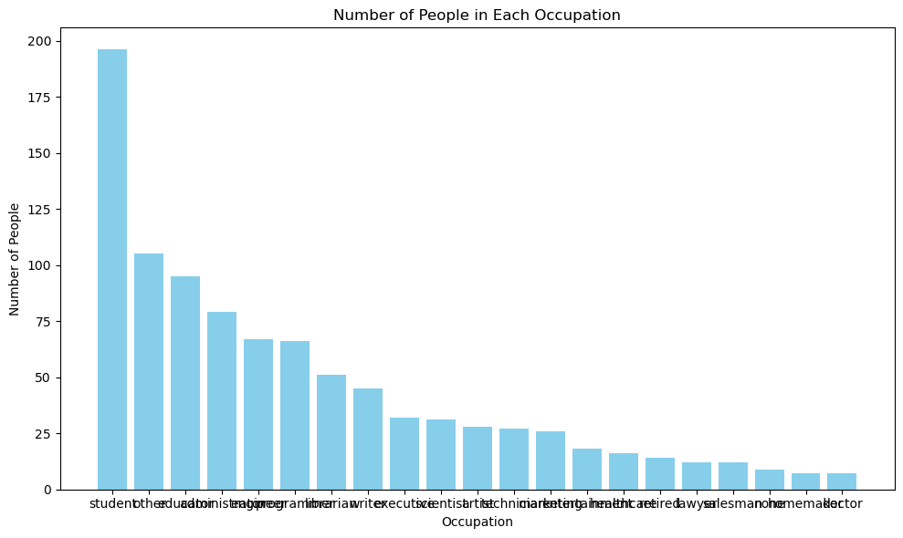

```python
plt.figure(figsize=(10, 6))
plt.bar(occupation_counts_sorted['Occupation'], occupation_counts_sorted['Number of People'], color='skyblue')
plt.xlabel('Occupation')
plt.ylabel('Number of People')
plt.title('Number of People in Each Occupation')

plt.tight_layout()
plt.show()
```

### Q21). Show a boxplot for age.

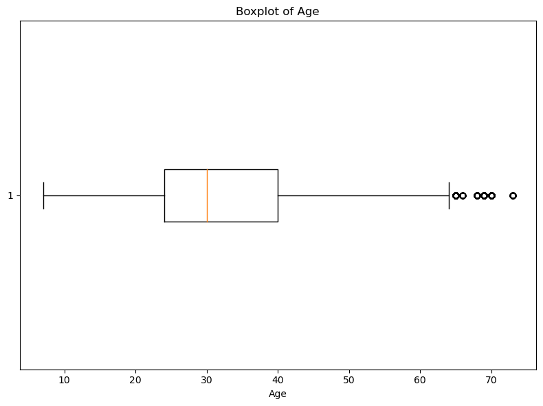

```python
plt.figure(figsize=(8, 6))
plt.boxplot(merged_df['age'], vert=False)
plt.xlabel('Age')
plt.title('Boxplot of Age')

plt.tight_layout()
plt.show()
```